# League Report Dashboard

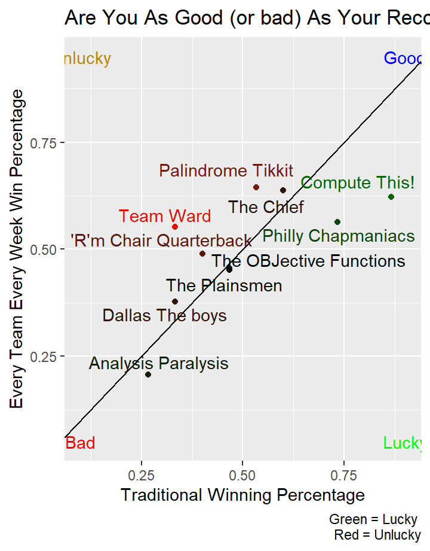

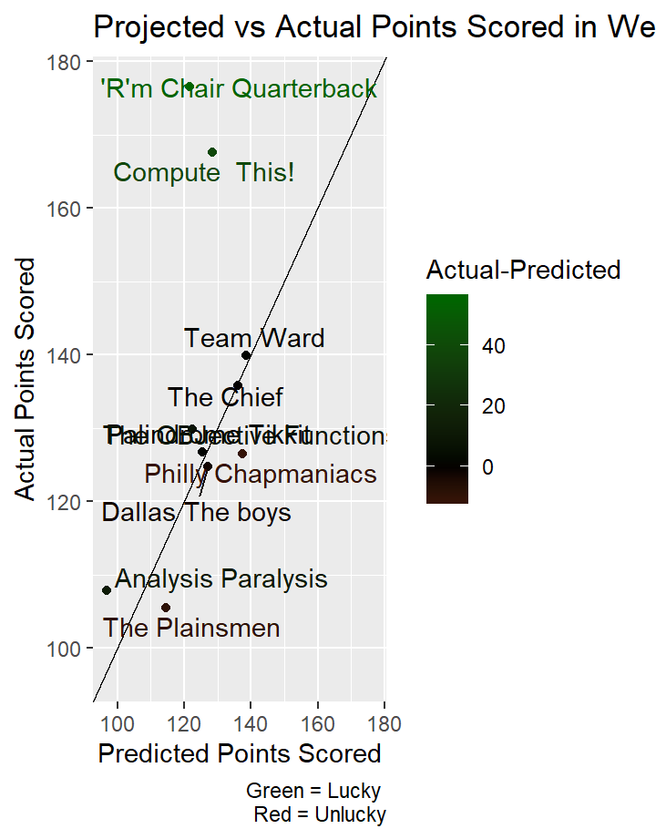

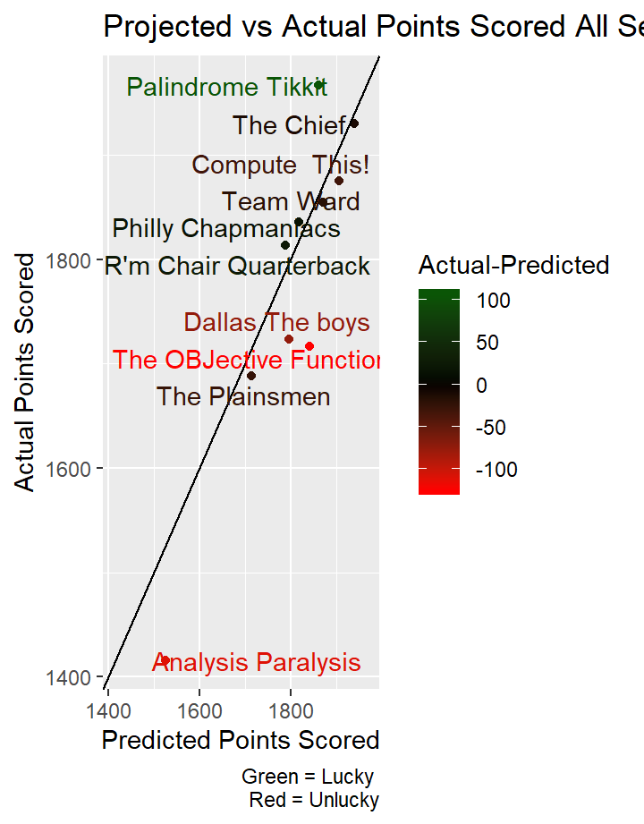

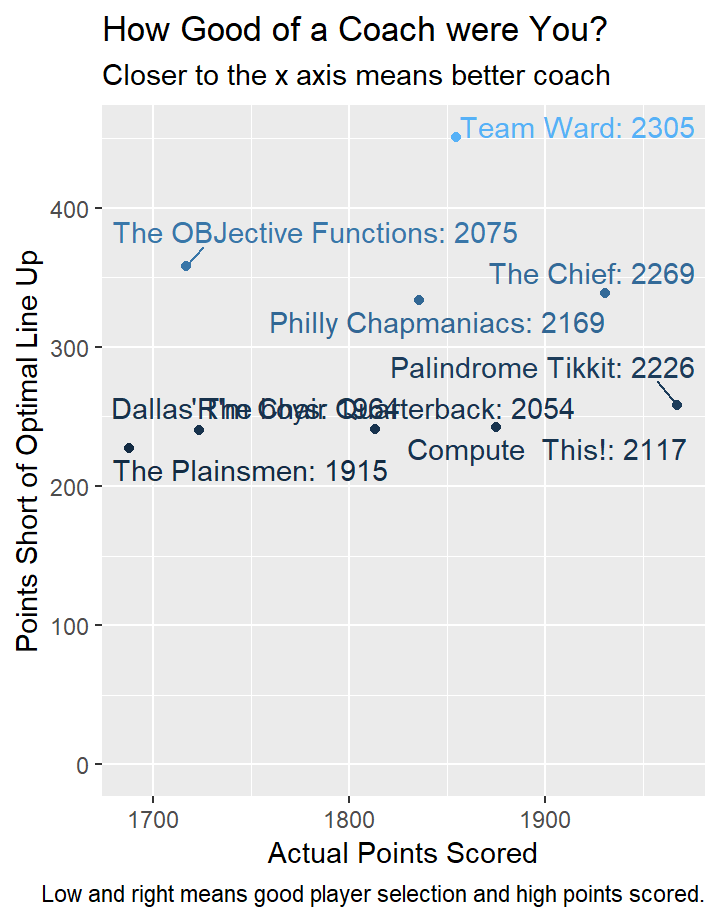

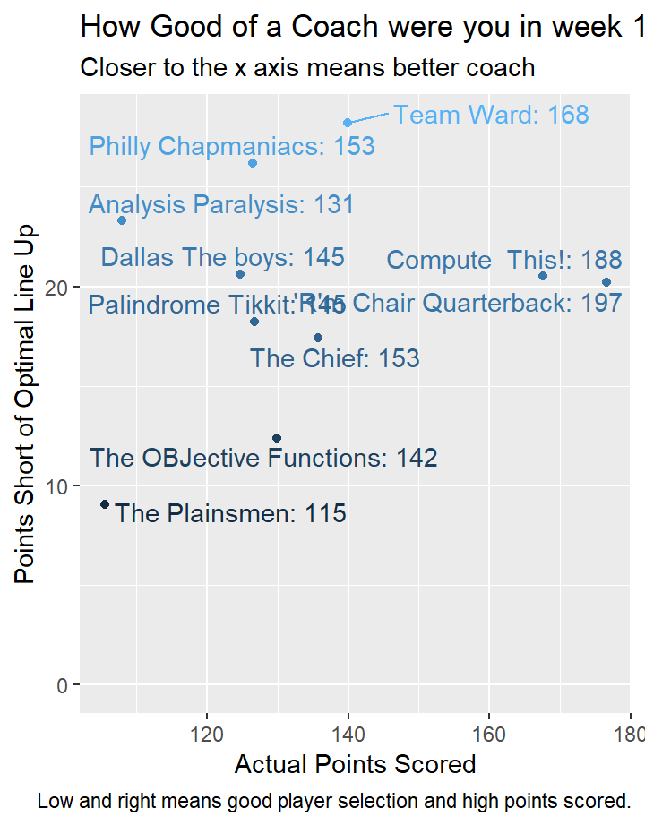

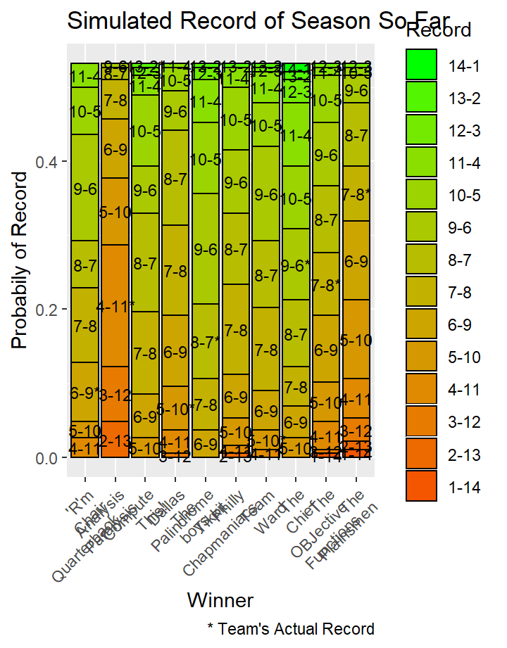

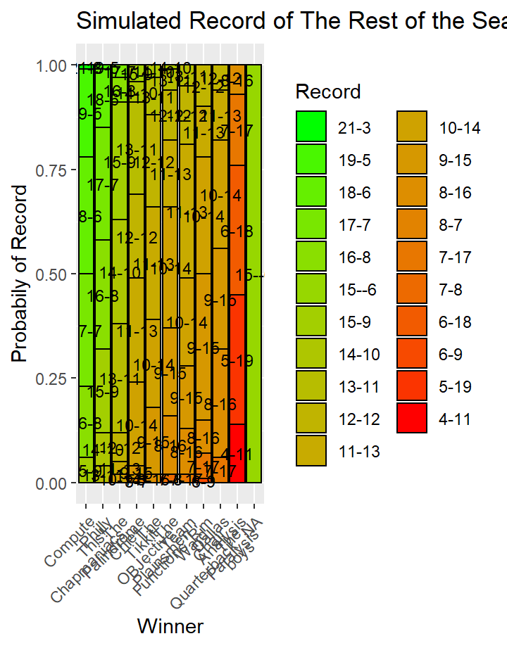

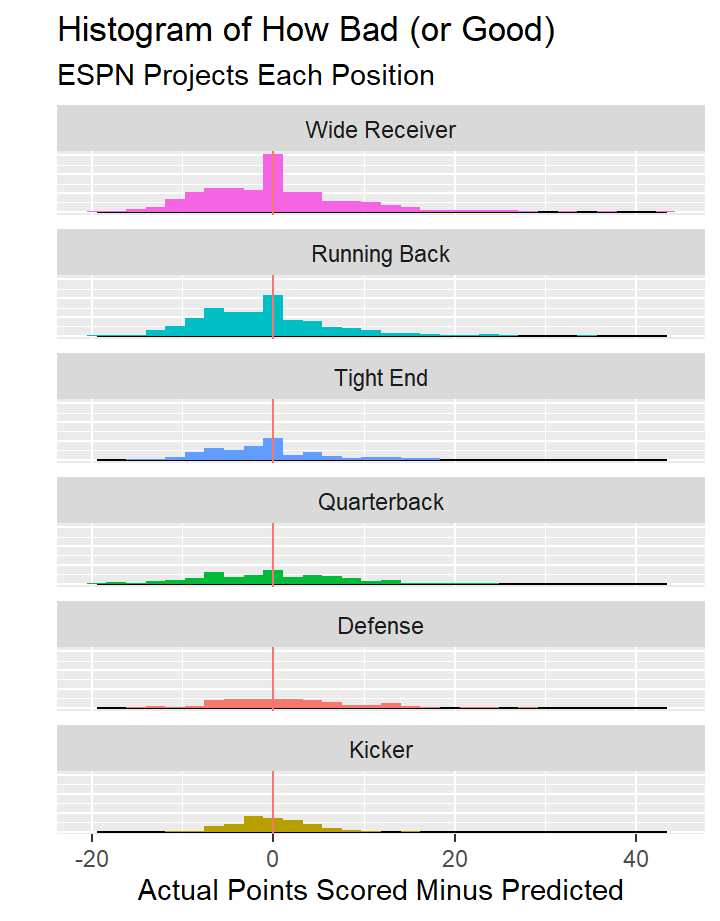

# Weekly Update

### Mug (and Plunger) Standings

Hello all, welcome to OA Division Fantasy Football Week 15 Update!

This page is an ongoing work in progress. Please send me an email at dusty.s.turner@gmail.com if you have any feedback.

All code is available on github.

Mug: Everyone congratulate ’R’m Chair Quarterback for winning the mug by scoring the most points this week.

Plunger: Hardy cajoling goes out to The Plainsmen for earning the plunger by scoring the lest points this week. Hats off for your hard work!

### Current Mug tally:

| Award | Team | n |
| --- | --- | --- |
| Mug | Palindrome Tikkit | 5 |
| Mug | ’R’m Chair Quarterback | 2 |
| Mug | The Plainsmen | 2 |
| Mug | Compute This! | 1 |
| Mug | Dallas The boys | 1 |
| Mug | Philly Chapmaniacs | 1 |
| Mug | Team Ward | 1 |
| Mug | The Chief | 1 |
| Mug | The OBJective Functions | 1 |

### Current Plunger tally:

| Award | Team | n |
| --- | --- | --- |
| Plunger | Analysis Paralysis | 6 |
| Plunger | The Plainsmen | 3 |
| Plunger | Philly Chapmaniacs | 2 |
| Plunger | ’R’m Chair Quarterback | 1 |
| Plunger | Compute This! | 1 |
| Plunger | Dallas The boys | 1 |
| Plunger | Palindrome Tikkit | 1 |

# Standings

### Standings

|  | Team | Wins | Losses | WinPerc | EveryWeekWins | EveryWeekLosses | EveryWeekPerc |
| --- | --- | --- | --- | --- | --- | --- | --- |
| 1 | Compute This! | 13 | 2 | 0.87 | 84 | 51 | 0.62 |
| 2 | Philly Chapmaniacs | 11 | 4 | 0.73 | 76 | 59 | 0.56 |
| 3 | The Chief | 9 | 6 | 0.6 | 86 | 49 | 0.64 |
| 4 | Palindrome Tikkit | 8 | 7 | 0.53 | 87 | 48 | 0.64 |
| 5 | The Plainsmen | 7 | 8 | 0.47 | 61 | 74 | 0.45 |
| 6 | The OBJective Functions | 7 | 8 | 0.47 | 61.5 | 73.5 | 0.46 |
| 7 | 'R'm Chair Quarterback | 6 | 9 | 0.4 | 66 | 69 | 0.49 |
| 8 | Team Ward | 5 | 10 | 0.33 | 74.5 | 60.5 | 0.55 |
| 9 | Dallas The boys | 5 | 10 | 0.33 | 51 | 84 | 0.38 |
| 10 | Analysis Paralysis | 4 | 11 | 0.27 | 28 | 107 | 0.21 |

### Graphic

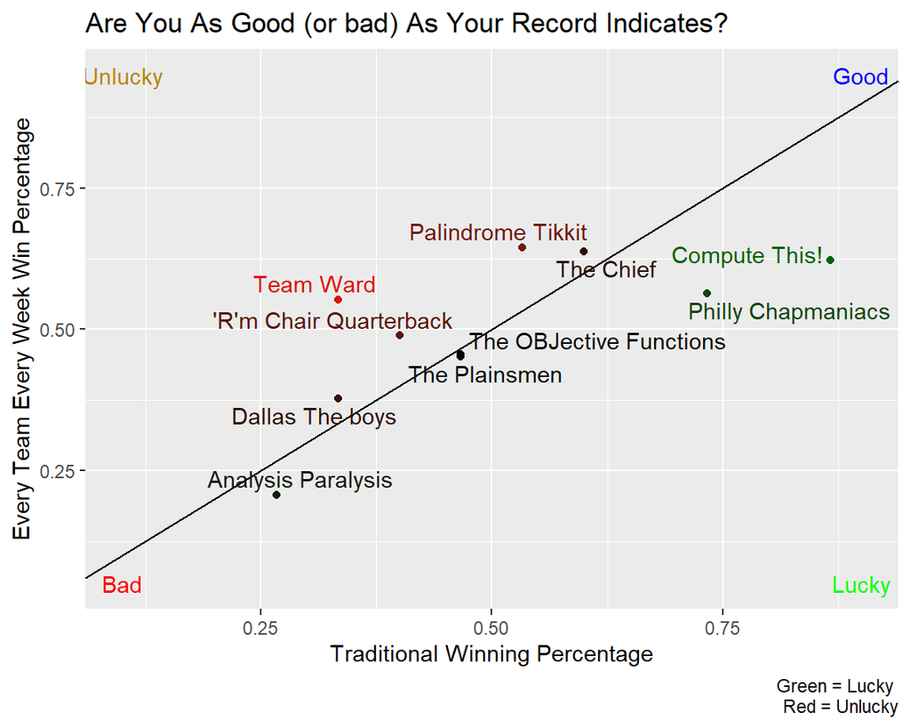

### Explanation

The standings are current through week 15.

Every week wins are how many wins your team would have if you played every team every week.

Every week losses and every week win percentage are calculated accordingly.

This is meant to be a measure of how ‘lucky’ your team is.

A graphical view of the above information. Low and right are lucky. Up and left are unlucky. .  
.  
.  
.  
.  
.  
.  
.  
.  
.  
.  
.  
.  
.  
.  
.  
.  
.

# Expectations

### What Teams Are Living Up to Expectations This Week?

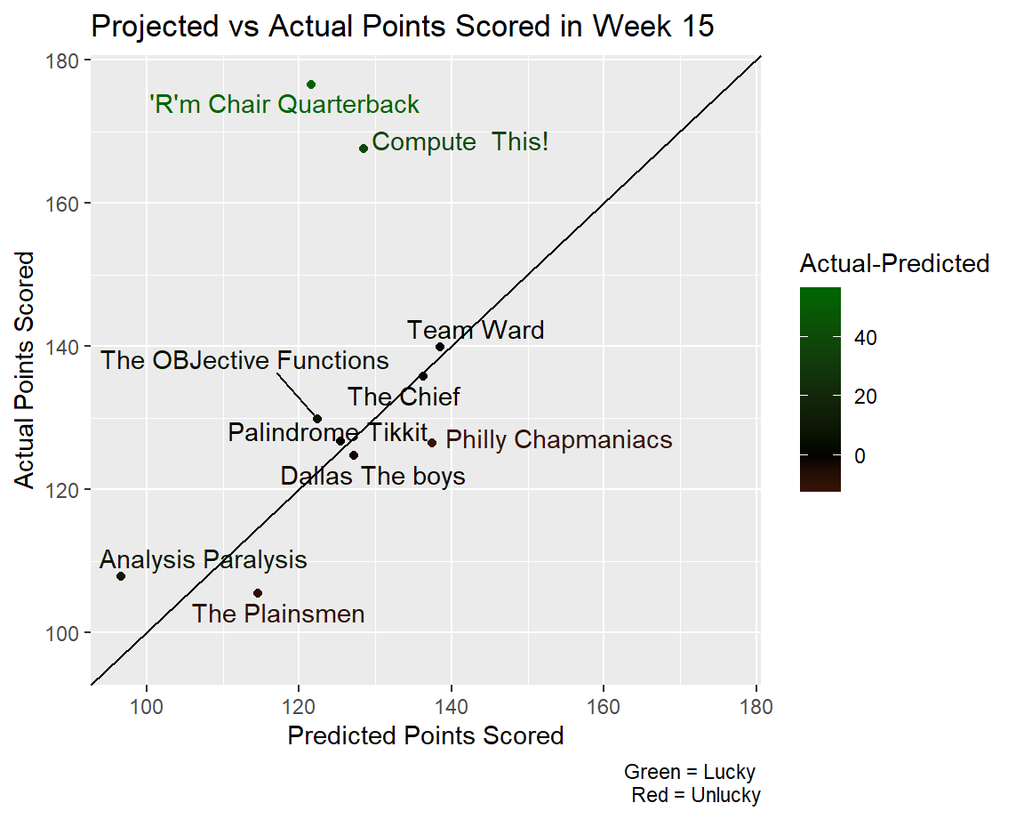

### Whose Team’s Starters Are Meeting Expectations?

This table shows the Team’s starter’s actual points scored minus their projected points scored in week 15.

|  | Team | Delta |
| --- | --- | --- |
| 1 | Philly_Chapmaniacs | -10.97 |
| 2 | The_Plainsmen | -9.07 |
| 3 | Dallas_The boys | -2.45 |
| 4 | The_Chief | -0.44 |
| 5 | Palindrome_Tikkit | 1.33 |
| 6 | Team_Ward | 1.41 |
| 7 | The OBJective_Functions | 7.45 |
| 8 | Analysis_Paralysis | 11.26 |
| 9 | Compute _This! | 39.19 |
| 10 | 'R'm Chair_Quarterback | 55 |

### What Teams Are Living Up to Expectations All Weeks?

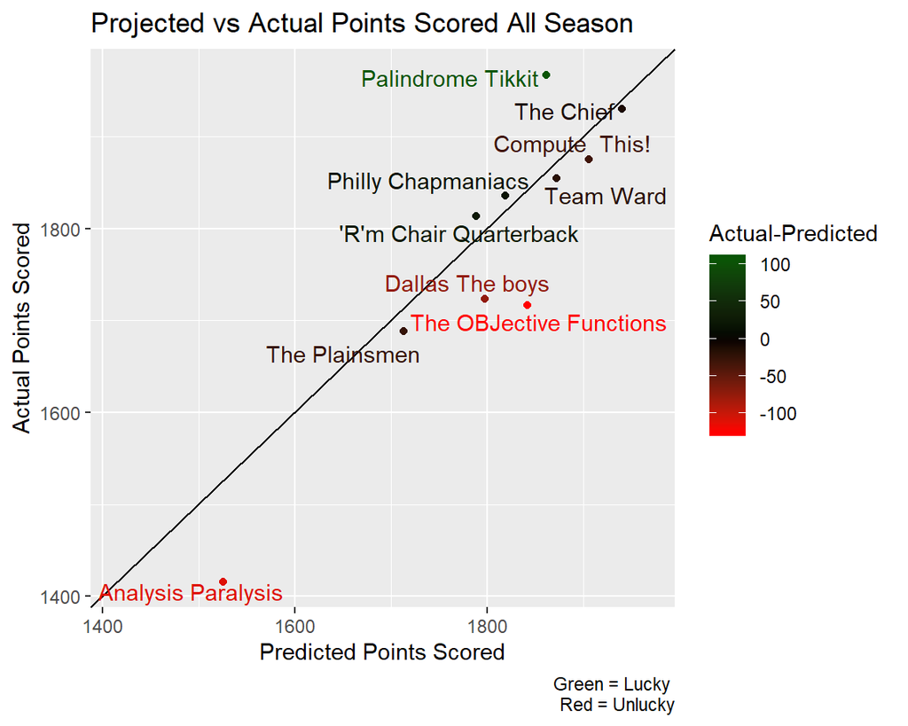

### Chart 4

This table show’s how each team’s starters have actually performed vs their projection (on average) all season.

|  | Team | Delta |
| --- | --- | --- |
| 1 | The OBJective_Functions | -124.85 |
| 2 | Analysis_Paralysis | -110.24 |
| 3 | Dallas_The boys | -74.09 |
| 4 | Compute _This! | -30.92 |
| 5 | The_Plainsmen | -25.4 |
| 6 | Team_Ward | -17.65 |
| 7 | The_Chief | -9.45 |
| 8 | Philly_Chapmaniacs | 16.58 |
| 9 | 'R'm Chair_Quarterback | 24.41 |
| 10 | Palindrome_Tikkit | 106.29 |

# Optimal Lineup

### Optimal Lineup All Weeks

Who is the best coach?

The plot below reflects how many

points you scored vs your best line up.

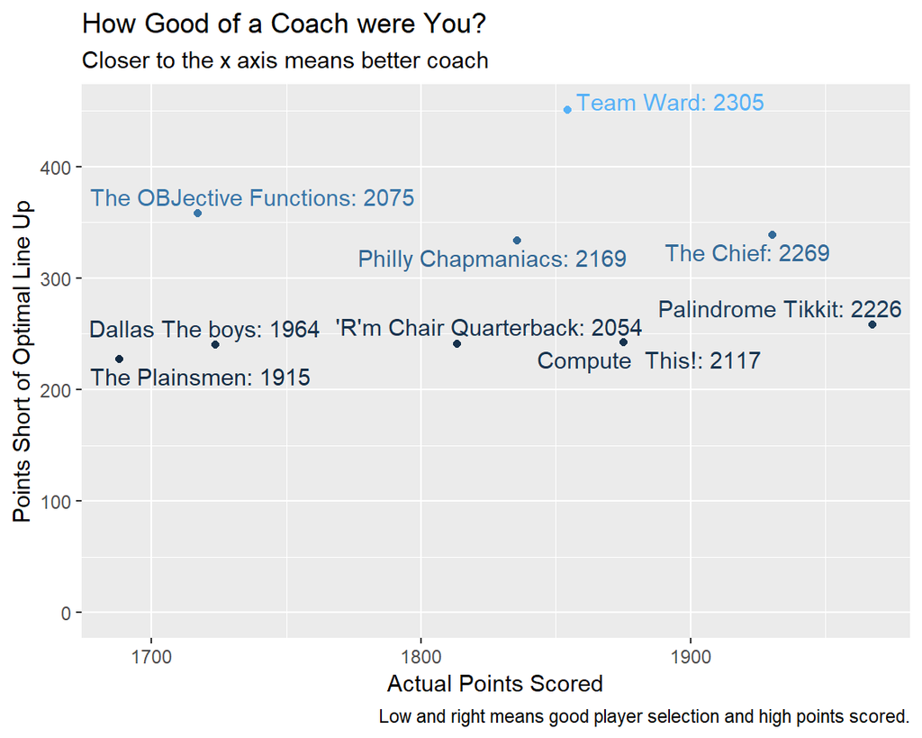

### Optimal Line Up in Week 15

How good of a coach were you in week 15?

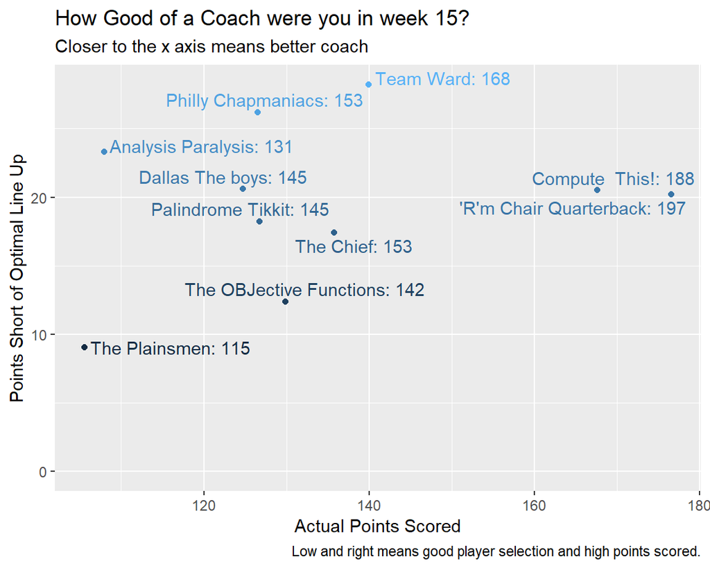

### What if you played your best roster each week?

The following table shows how well your team could be doing if you played your best roster every week.

|  | Team | Wins | Losses | WinPerc |
| --- | --- | --- | --- | --- |
| 1 | Philly Chapmaniacs | 11 | 4 | 0.73 |
| 2 | Compute This! | 11 | 4 | 0.73 |
| 3 | Team Ward | 9 | 6 | 0.6 |
| 4 | Palindrome Tikkit | 9 | 6 | 0.6 |
| 5 | 'R'm Chair Quarterback | 8 | 7 | 0.53 |
| 6 | The Chief | 8 | 7 | 0.53 |
| 7 | Dallas The boys | 5 | 10 | 0.33 |
| 8 | The OBJective Functions | 5 | 10 | 0.33 |
| 9 | Analysis Paralysis | 5 | 10 | 0.33 |
| 10 | The Plainsmen | 4 | 11 | 0.27 |

# Season Sims

### Season Simulation Through This Week

Sim providing distribution of possible records.

```
# A tibble: 10 x 3
   Winner                  sorter ActualRecord
   <chr>                    <dbl> <chr>
 1 'R'm Chair Quarterback     5.5 6-9
 2 Analysis Paralysis         5.5 4-11
 3 Compute This!              5.5 13-2
 4 Dallas The boys            5.5 5-10
 5 Palindrome Tikkit          5.5 8-7
 6 Philly Chapmaniacs         5.5 11-4
 7 Team Ward                  5.5 5-10
 8 The Chief                  5.5 9-6
 9 The OBJective Functions    5.5 7-8
10 The Plainsmen              5.5 7-8
```

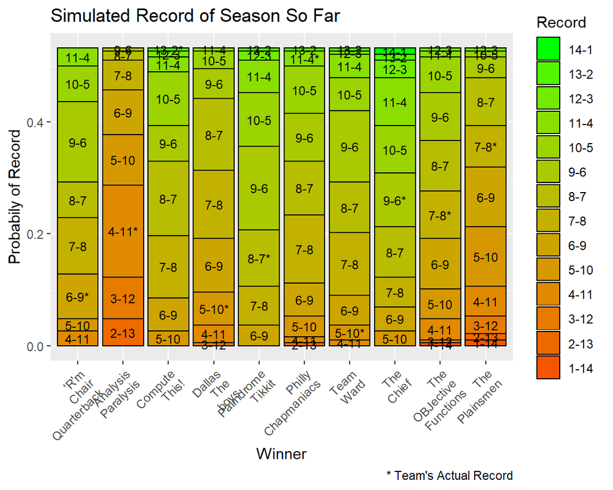

### Simulation from current week through rest of season

[figure not shown]

# Misc Comparisons

### What Positions Are Predicted Most Accurately

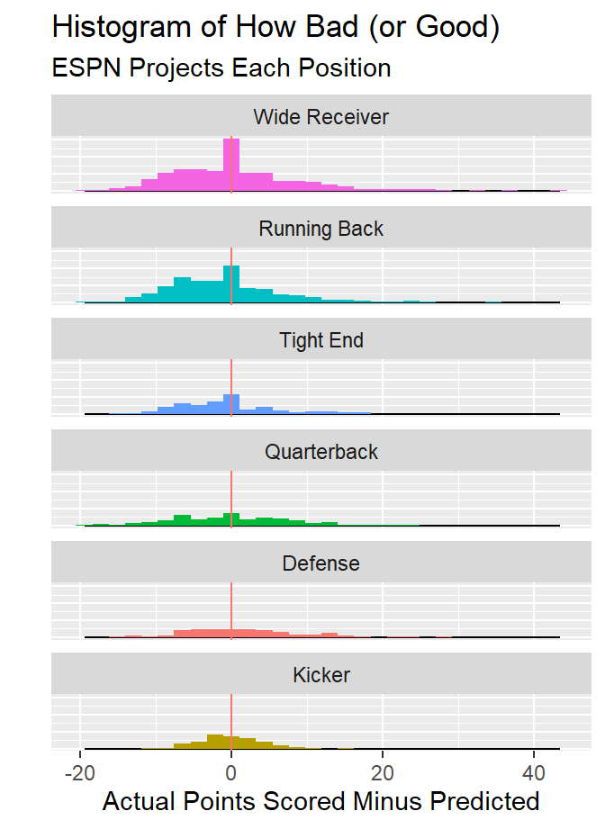

### Performance By Position Compared To Other Teams

[interactive chart not shown]